# United States Digital Corps Project-Based Assessment

# Before we start modeling, let’s check the distribution of diabetes

```r
prop.table(table(data4_sample$diabete3))
```

```
##
##         0         1
## 0.8614575 0.1385425
```

##### Given the result above, I considered over and undersampling the data because of the 86/14 split on no diabetes/diabetes and was worried that the imbalance would skew the model. However, I decided against it for the following reasons:

###### According to the National Diabetes Statistics Report (2014), 9.3% of the U.S. population has diabetes, meaning that we are not necessarily aiming for a 50/50 split and our sample is relatively representative of the US. Of the 9.3%, 27.8% are undiagnosed which our model aims to solve for. Because we are interested in accurate prediction and I believe the data is representative, we do not have to correct.

###### There is a large risk of overfitting in the over-sampled model

###### Under-sampling would reduce the sample and undermine its effectiveness

###### The usefulness (AUC value) of the over, under, and non-sampled models would remain the same (or be very close to each other). This is because changing the class ratio only affects the intercept of a standard logistic regression model. It is a monotonic transformation of the log-odds. This also represents a monotonic function of the predicted probability values. Monotonic functions preserve order, and AUC stays the same with order meaning the AUC does not change.

# Section 3.1: Model Selection:

## Use the Boruta algorithm to see what variables are relevant in the data. Based on the earlier visualization, we omit numadult, drvisits, mscode, income2, and hlthcvr1 because they are largely missing from the data and we will not use them as predictors because of that.

```r
boruta_data <- data4_sample %>%
  select(-c(Freq, perc_total_respondents, personid,weight_correct))
```

```
## select: dropped 4 variables (personid, weight_correct, Freq, perc_total_respondents)
```

```r
#Omit varialbes that we don't intend on using in our model
boruta.train <- Boruta(diabete3~., data = boruta_data)
# Confirmed, non-tentative: The following variables are predictive and should be kept.
# children, genhlth, ageg5yr,bmi5cat, educag, sleptim1, menthlth, race, employ1, cvdcrhd4, chckidny, useequip, addepev2, exerany2, decide, marital, sex
# Tentative. The algorithm was indecisive about if these are predictive. It is up to us to include.
# checkup1, smoker3, totinda
```

## Create correlation plot for selected variables

[figure not shown]

```r
model.matrix(~0+.-Freq-perc_total_respondents-personid-state, data=data4_sample) %>%
     cor(use="pairwise.complete.obs") %>%
     ggcorrplot(show.diag = F, type="lower", lab=TRUE, lab_size=2)
```

```r
# Given the figure, omit totinda
# No physical activity in the past 30 days is 100% correlated with no physical exercise in the past 30 days. Because totinda is a tentative attribute according to the Boruta algorithm, we opt to use exerany.
```

# Section 3.2: Look into all of the variables specified by Boruta:

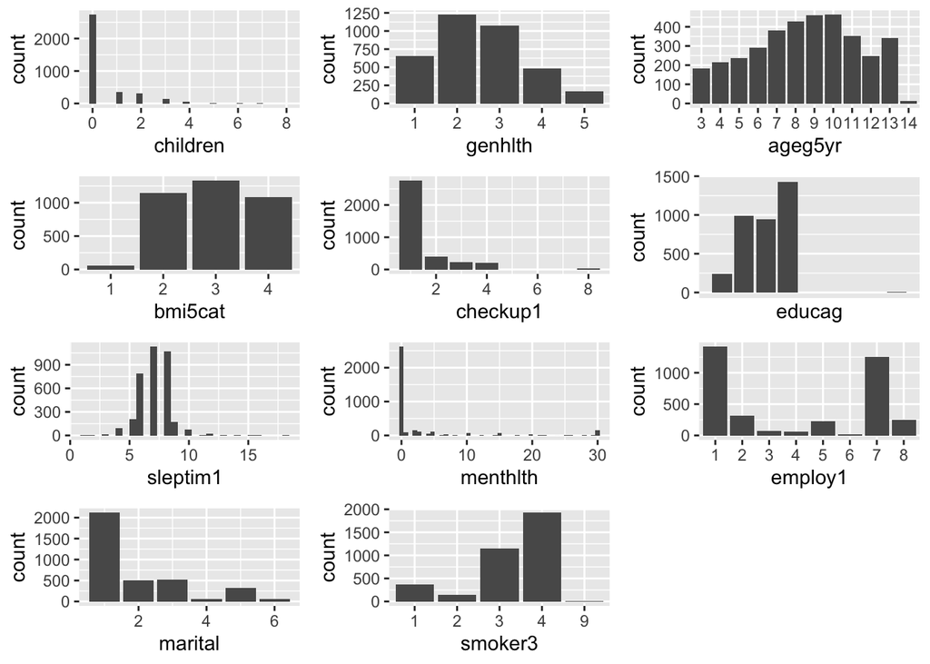

```r
children_hist <- ggplot(data4_sample, aes(x=children)) + geom_histogram()
genhlth_hist <- ggplot(data4_sample, aes(x=genhlth)) + geom_bar()
ageg5yr_hist <- ggplot(data4_sample, aes(x=ageg5yr)) + geom_bar()
bmi5cat_hist <- ggplot(data4_sample, aes(x=bmi5cat)) + geom_bar()
checkup_hist <- ggplot(data4_sample, aes(x=checkup1)) + geom_bar()
educag_hist <- ggplot(data4_sample, aes(x=educag)) + geom_bar()+
  scale_x_discrete(breaks=c(1, 2, 3, 4, 5, 6, 7, 8, 9))
sleptim_hist <- ggplot(data4_sample, aes(x=sleptim1)) + geom_histogram()
menthlth_hist <- ggplot(data4_sample, aes(x=menthlth)) + geom_histogram(bins=45)
employ1_hist <- ggplot(data4_sample, aes(x=employ1)) + geom_bar()
cvdcrhd4_table <- table(data4_sample$cvdcrhd4)
chckidny_table <- table(data4_sample$chckidny)
useequip_table <- table(data4_sample$useequip)
addepev2_table <- table(data4_sample$addepev2)
exerany_table <- table(data4_sample$exerany2)
decide_table <- table(data4_sample$decide)
marital_hist <- ggplot(data4_sample, aes(x=marital)) + geom_bar()
sex_table <- table(data4_sample$sex)
smoker3_hist <- ggplot(data4_sample, aes(x=smoker3)) + geom_bar()
totinda_table <- table(data4_sample$totinda)


grid.arrange(children_hist, genhlth_hist, ageg5yr_hist, bmi5cat_hist, checkup_hist, educag_hist, sleptim_hist, menthlth_hist,employ1_hist, marital_hist, smoker3_hist, ncol=3, nrow =4)
```

# Section 3.3: Split the data into training and test sets before adjusting the samples.

```r
train <- data4_sample %>%
  dplyr::sample_frac(0.75) %>%
  group_by(race) %>%
  mutate(perc_population = case_when(race == 1 ~  77.5,
                                     race == 2 ~ 13.2,
                                     race == 3 ~ 1.2,
                                     race == 4 ~ 5.4,
                                     race == 5 ~ 0.2,
                                     race == 7 ~ 2.5,
                         TRUE~15.3)) %>%
  ## Used https://www.census.gov/content/dam/Census/library/publications/2015/demo/p25-1143.pdf page 9
  ## subtracted 2.1 from the hispanic because we have 17.4 percent hispanic and that is not ONLY hispanic
  mutate(race_weight = perc_population/perc_total_respondents) %>%
  select(-c(perc_population, perc_total_respondents, Freq)) %>%
  ungroup()
```

```
## group_by: one grouping variable (race)
```

```
## mutate (grouped): new variable 'perc_population' (double) with 7 unique values and 0% NA
```

```
## mutate (grouped): new variable 'race_weight' (double) with 7 unique values and 0% NA
```

```
## select: dropped 3 variables (Freq, perc_total_respondents, perc_population)
```

```
## ungroup: no grouping variables
```

```r
prop.table(table(train$diabete3))
```

```
##
##         0         1
## 0.8699668 0.1300332
```

```r
# Creating test sample-- still need to create a racially representative sample here as well before testing the model we created
test  <- dplyr::anti_join(data4_sample, train, by = 'personid') %>%
  group_by(race) %>%
  mutate(Freq=n()) %>%
  mutate(perc_total_respondents = Freq/3808*100) %>%
  mutate(perc_population = case_when(race == 1 ~  77.5,
                                     race == 2 ~ 13.2,
                                     race == 3 ~ 1.2,
                                     race == 4 ~ 5.4,
                                     race == 5 ~ 0.2,
                                     race == 7 ~ 2.5,
                         TRUE~15.3)) %>%
  # Used https://www.census.gov/content/dam/Census/library/publications/2015/demo/p25-1143.pdf page 9
  # subtracted 2.1 from the hispanic because we have 17.4 percent hispanic and that is not ONLY hispanic
  mutate(race_weight = perc_population/perc_total_respondents) %>%
  select(-c(perc_population, perc_total_respondents, Freq)) %>%
  ungroup()
```

```
## group_by: one grouping variable (race)
```

```
## mutate (grouped): changed 902 values (100%) of 'Freq' (0 new NA)
```

```
## mutate (grouped): changed 902 values (100%) of 'perc_total_respondents' (0 new NA)
```

```
## mutate (grouped): new variable 'perc_population' (double) with 7 unique values and 0% NA
```

```
## mutate (grouped): new variable 'race_weight' (double) with 7 unique values and 0% NA
```

```
## select: dropped 3 variables (Freq, perc_total_respondents, perc_population)
```

```
## ungroup: no grouping variables
```

```r
prop.table(table(test$diabete3))
```

```
##
##         0         1
## 0.8359202 0.1640798
```

# Section 4: Deploying the logit model

## We can use a logit model to predict if someone will be diagnosed with diabetes.

## Run the regression and examine the results

```r
mylogit <- glm(diabete3 ~children+genhlth+ageg5yr+bmi5cat+checkup1+educag+sleptim1+menthlth+race+employ1+cvdcrhd4+chckidny+useequip+addepev2+exerany2+decide+marital+sex+smoker3, data = train, family = binomial(link = "logit"), weights = race_weight)
anova_logit <- anova(mylogit, test="Chisq")
```

[output not shown]

```r
# Use a chi-squared test because we have a lot of categorical and ordinal variables. The p values we have in the regression output correspond to individual Wald tests, but those p values do not tell us if the entire categorical/ordinal variable) explains the probability of getting diabetes. We have to test the coefficients together, so we perform a deviance goodness of fit test.
```

## View regression output

```r
summary(mylogit)
```

```
##
## Call:
## glm(formula = diabete3 ~ children + genhlth + ageg5yr + bmi5cat +
##     checkup1 + educag + sleptim1 + menthlth + race + employ1 +
##     cvdcrhd4 + chckidny + useequip + addepev2 + exerany2 + decide +
##     marital + sex + smoker3, family = binomial(link = "logit"),
##     data = train, weights = race_weight)
##
## Deviance Residuals:
##     Min       1Q   Median       3Q      Max
## -2.5451  -0.5499  -0.3078  -0.1280   4.6033
##
## Coefficients:
##              Estimate Std. Error z value Pr(>|z|)
## (Intercept) -5.968464   1.103556  -5.408 6.36e-08 ***
## children     0.081073   0.080519   1.007 0.313993
## genhlth2     1.368731   0.339095   4.036 5.43e-05 ***
## genhlth3     1.872357   0.331397   5.650 1.61e-08 ***
## genhlth4     2.298294   0.345982   6.643 3.08e-11 ***
## genhlth5     2.617605   0.393615   6.650 2.93e-11 ***
## ageg5yr4     0.525956   0.817569   0.643 0.520018
## ageg5yr5     1.402070   0.738159   1.899 0.057510 .
## ageg5yr6     1.723306   0.733141   2.351 0.018744 *
## ageg5yr7     2.415389   0.703694   3.432 0.000598 ***
## ageg5yr8     2.597914   0.709253   3.663 0.000249 ***
## ageg5yr9     3.086862   0.708793   4.355 1.33e-05 ***
## ageg5yr10    2.915876   0.717401   4.064 4.81e-05 ***
## ageg5yr11    2.933734   0.726704   4.037 5.41e-05 ***
## ageg5yr12    3.631177   0.733084   4.953 7.30e-07 ***
## ageg5yr13    2.962661   0.738101   4.014 5.97e-05 ***
## ageg5yr14    3.458971   1.090264   3.173 0.001511 **
## bmi5cat2    -0.045946   0.588672  -0.078 0.937788
## bmi5cat3     0.514411   0.580543   0.886 0.375571
## bmi5cat4     1.303108   0.578966   2.251 0.024401 *
## checkup1    -0.403097   0.099499  -4.051 5.09e-05 ***
## educag      -0.057098   0.060650  -0.941 0.346487
## sleptim1     0.005765   0.037553   0.154 0.877989
## menthlth    -0.006718   0.008747  -0.768 0.442419
## race2        0.656545   0.172045   3.816 0.000136 ***
## race3        0.437356   0.530508   0.824 0.409706
```

[output cut: 18 more lines]

```
## sex2        -0.197088   0.123220  -1.599 0.109712
## smoker32    -0.706187   0.381994  -1.849 0.064503 .
## smoker33     0.193401   0.222126   0.871 0.383929
## smoker34     0.173282   0.219062   0.791 0.428934
## smoker39     1.238588   0.737107   1.680 0.092892 .
## ---
## Signif. codes:  0 '***' 0.001 '**' 0.01 '*' 0.05 '.' 0.1 ' ' 1
##
## (Dispersion parameter for binomial family taken to be 1)
##
##     Null deviance: 2664.2  on 2706  degrees of freedom
## Residual deviance: 2029.6  on 2658  degrees of freedom
## AIC: 2202.5
##
## Number of Fisher Scoring iterations: 7
```

```r
anova_logit
```

```
## Analysis of Deviance Table
##
## Model: binomial, link: logit
##
## Response: diabete3
##
## Terms added sequentially (first to last)
##
##
##          Df Deviance Resid. Df Resid. Dev  Pr(>Chi)
## NULL                      2706     2664.2
## children  1   43.756      2705     2620.4 3.720e-11 ***
## genhlth   4  259.228      2701     2361.2 < 2.2e-16 ***
## ageg5yr  11  109.165      2690     2252.0 < 2.2e-16 ***
## bmi5cat   3   96.933      2687     2155.1 < 2.2e-16 ***
## checkup1  1   21.884      2686     2133.2 2.897e-06 ***
## educag    1    2.629      2685     2130.6   0.10494
## sleptim1  1    0.061      2684     2130.5   0.80536
## menthlth  1    0.835      2683     2129.7   0.36094
## race      6   39.764      2677     2089.9 5.068e-07 ***
## employ1   7   14.333      2670     2075.6   0.04557 *
## cvdcrhd4  1   18.204      2669     2057.4 1.985e-05 ***
## chckidny  1    1.722      2668     2055.6   0.18939
## useequip  1    0.618      2667     2055.0   0.43196
## addepev2  1    3.029      2666     2052.0   0.08177 .
## exerany2  1    0.001      2665     2052.0   0.97603
## decide    1    5.982      2664     2046.0   0.01445 *
## marital   1    2.991      2663     2043.0   0.08375 .
## sex       1    2.680      2662     2040.3   0.10164
## smoker3   4   10.712      2658     2029.6   0.03000 *
## ---
## Signif. codes:  0 '***' 0.001 '**' 0.01 '*' 0.05 '.' 0.1 ' ' 1
```

```r
# How to interpret this test: rejecting the null means the reduction in deviance is larger than one would expect if a variable did not explain anything about the outcome
```

## Section 4.1: Make predictions using test data

```r
probabilities <- mylogit %>% predict(test, type = "response")
# The result is continuous values of probabilities of diabetes occurrence, but we are interested in predicting if someone will have diabetes or not. If anyone has a probability above 50%, we assume that they will be diagnosed with diabetes.
predicted_classes <- ifelse(probabilities > 0.5, 1, 0)
```

## Section 4.2: Evaluate the model by creating a confusion matrix

```r
# Take the predictions and append as a column to the test dataframe to create a confusion matrix
# Do do that, we must first converting predicted classes to a dataframe
predicted_classes_logit <- as.data.frame(predicted_classes)
test_predicted_logit <- cbind(predicted_classes_logit, test)
logitconfusionmatrix <-confusionMatrix(data=as.factor(test_predicted_logit$predicted_classes), reference=as.factor(test_predicted_logit$diabete3))
```

```r
logitconfusionmatrix
```

```
## Confusion Matrix and Statistics
##
##           Reference
## Prediction   0   1
##          0 736 126
##          1  18  22
##
##                Accuracy : 0.8404
##                  95% CI : (0.8148, 0.8637)
##     No Information Rate : 0.8359
##     P-Value [Acc > NIR] : 0.38
##
##                   Kappa : 0.1765
##
##  Mcnemar's Test P-Value : <2e-16
##
##             Sensitivity : 0.9761
##             Specificity : 0.1486
##          Pos Pred Value : 0.8538
##          Neg Pred Value : 0.5500
##              Prevalence : 0.8359
##          Detection Rate : 0.8160
##    Detection Prevalence : 0.9557
##       Balanced Accuracy : 0.5624
##
##        'Positive' Class : 0
##
```

## Section 4.3: Create ROC Curve to calculate the performance of the classification model

```r
roc_object <- roc(test$diabete3, probabilities)
```

```r
# Calculate area under curve, the closer this is to 1 the more useful the model is
auc_logit <- auc(roc_object)
auc_logit
```

```
## Area under the curve: 0.814
```

# Section 5: Decision trees

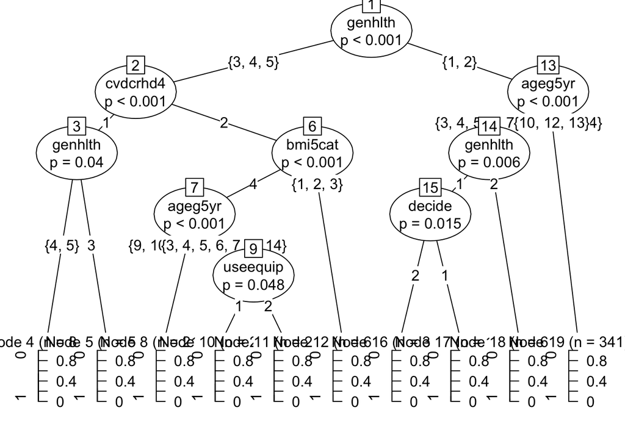

```r
decisiontree <- ctree(diabete3 ~children+genhlth+ageg5yr+bmi5cat+checkup1+educag+sleptim1+menthlth+race+employ1+cvdcrhd4+chckidny+useequip+addepev2+exerany2+decide+marital+sex+smoker3, data = train)
plot(decisiontree)
```

## Section 5.1: Make predictions using test data

```r
predict_model<-predict(decisiontree, test)
```

## Section 5.2: Evaluate the model by creating a confusion matrix

```r
predicted_classes_decisiontree <- as.data.frame(predict_model)
test_predicted_decisiontree <- cbind(predicted_classes_decisiontree, test)

decisiontree_confusionmatrix<-confusionMatrix(data=test_predicted_decisiontree$predict_model, reference=test_predicted_decisiontree$diabete3)
```

```r
decisiontree_confusionmatrix
```

```
## Confusion Matrix and Statistics
##
##           Reference
## Prediction   0   1
##          0 740 133
##          1  14  15
##
##                Accuracy : 0.837
##                  95% CI : (0.8113, 0.8606)
##     No Information Rate : 0.8359
##     P-Value [Acc > NIR] : 0.4861
##
##                   Kappa : 0.1223
##
##  Mcnemar's Test P-Value : <2e-16
##
##             Sensitivity : 0.9814
##             Specificity : 0.1014
##          Pos Pred Value : 0.8477
##          Neg Pred Value : 0.5172
##              Prevalence : 0.8359
##          Detection Rate : 0.8204
##    Detection Prevalence : 0.9678
##       Balanced Accuracy : 0.5414
##
##        'Positive' Class : 0
##
```

## Section 5.3: Create ROC Curve to calculate the performance of the classification model

```r
predict_model <- as.numeric(predict_model)
roc_object_decisiontree <- roc(test$diabete3, predict_model)
```

```r
# Calculate area under curve, the closer this is to 1 the more useful the model is
auc_decisiontree <- auc(roc_object_decisiontree)
auc_decisiontree
```

```
## Area under the curve: 0.5414
```

# Section 6: Random Forests

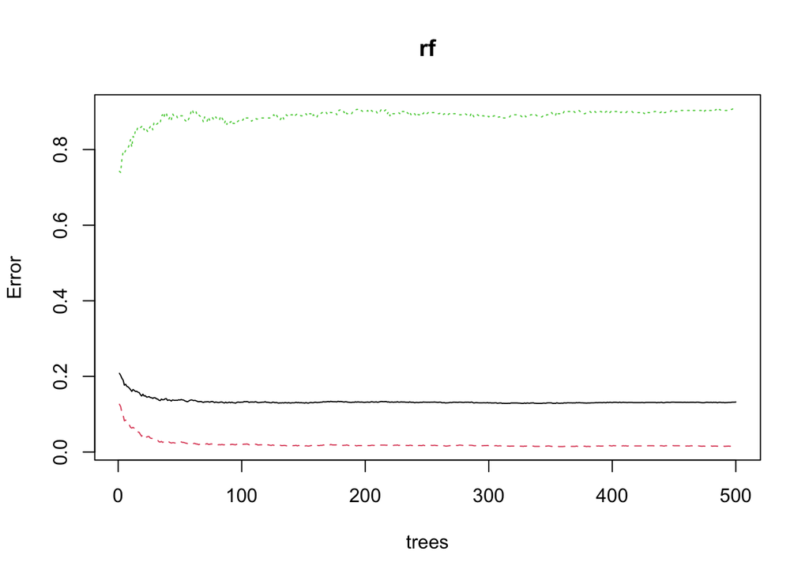

```r
rf <- randomForest(diabete3 ~children+genhlth+ageg5yr+bmi5cat+checkup1+educag+sleptim1+menthlth+race+employ1+cvdcrhd4+chckidny+useequip+addepev2+exerany2+decide+marital+sex+smoker3, data=train, proximity=TRUE, ntree=500)
plot(rf)
```

## Section 6.1: Make predictions using test data

```r
pred_randomforest_test <- predict(rf, newdata = test, type= "class")
```

## Section 6.2: Evaluate the model by creating a confusion matrix

```r
test_predicted_randomforest <- cbind(pred_randomforest_test, test)

confusionmatrixRandomForest <- confusionMatrix(data=as.factor(test_predicted_randomforest$pred_randomforest_test),
                                               reference=as.factor(test_predicted_randomforest$diabete3))
```

```r
confusionmatrixRandomForest
```

```
## Confusion Matrix and Statistics
##
##           Reference
## Prediction   0   1
##          0 742 136
##          1  12  12
##
##                Accuracy : 0.8359
##                  95% CI : (0.8101, 0.8595)
##     No Information Rate : 0.8359
##     P-Value [Acc > NIR] : 0.5219
##
##                   Kappa : 0.0982
##
##  Mcnemar's Test P-Value : <2e-16
##
##             Sensitivity : 0.98408
##             Specificity : 0.08108
##          Pos Pred Value : 0.84510
##          Neg Pred Value : 0.50000
##              Prevalence : 0.83592
##          Detection Rate : 0.82262
##    Detection Prevalence : 0.97339
##       Balanced Accuracy : 0.53258
##
##        'Positive' Class : 0
##
```

## Section 6.3: Create ROC Curve to calculate the performance of the classification model

```r
pred_randomforest_test <-  as.numeric(pred_randomforest_test)
# create roc curve
roc_object_randomforests <- roc(test$diabete3, pred_randomforest_test)
# calculate area under curve
auc_randomforests <- auc(roc_object_randomforests)
auc_randomforests
```

```
## Area under the curve: 0.5326
```